# Mayoral Appointee Salaries

> by Devon Ankar for class DSE 6000 @ Wayne State University

[Salary information for all mayoral appointees](https://data.detroitmi.gov/Government/Mayoral-Appointee-Salaries/fwu6-4nb5)

Anyone who lives or works in Detroit pays taxes to the city, so we want to know where that money is going. We want to find key facts about where our taxpayer dollars are going.

**Question:** Which departments have the highest mean salaries?

**Initial hypothesis:** Mayor's Office will have the highest mean salary

```python
import pandas as pd
import numpy as np
import matplotlib.pyplot as plt
import seaborn as sns

salaries = pd.read_csv('Mayoral_Appointee_Salaries.csv', encoding = "ISO-8859-1")

salaries.head(10)
```

|  | LAST NAME | FIRST NAME | TITLE | DEPARTMENT/AREA | CITY SALARY | CONTRACTOR | ADDITIONAL GRANT SUPPORT | TOTAL SALARY | GRANT SUPPORTER | Note |
| --- | --- | --- | --- | --- | --- | --- | --- | --- | --- | --- |
| 0 | Ali | Mona | Deputy District Manager | Mayor's Office | $59360.31 | NaN | $0.00 | $59360.31 | NaN | NaN |
| 1 | Anderson | Janet G. | Deputy Director | General Services | $122939.00 | NaN | $0.00 | $122939.00 | NaN | NaN |
| 2 | Azar | Letty | District Manager | Mayor's Office | $82736.97 | NaN | $0.00 | $82736.97 | NaN | NaN |
| 3 | Barnett | Jasmine | Director of Constituent Affairs | Mayor's Office | $56999.99 | NaN | $0.00 | $56999.99 | NaN | NaN |
| 4 | Barnhill | Bryan C II | Chief Talent Officer | Mayor's Office | $114728.25 | NaN | $0.00 | $114728.25 | NaN | NaN |
| 5 | Beckham | Charles | Group Executive of Neighborhoods | Mayor's Office | $151214.00 | NaN | $0.00 | $151214.00 | NaN | NaN |
| 6 | Bell Jr. | David | Director | Buildings and Safety Engineering | $154977.00 | NaN | $0.00 | $154977.00 | NaN | NaN |
| 7 | Blanks-Smart | Miriam | Director | Administrative Hearings | $115568.00 | NaN | $0.00 | $115568.00 | NaN | NaN |
| 8 | Brown | Gary | Director | Water and Sewerage | $175001.00 | NaN | $0.00 | $175001.00 | NaN | NaN |
| 9 | Brundidge | Ron | Director | Public Works | $139219.00 | NaN | $0.00 | $139219.00 | NaN | NaN |

```python
salaries.columns
```

```
Index(['LAST NAME', 'FIRST NAME', 'TITLE', 'DEPARTMENT/AREA', 'CITY SALARY',
       'CONTRACTOR', 'ADDITIONAL GRANT SUPPORT', 'TOTAL SALARY',
       'GRANT SUPPORTER', 'Note'],
      dtype='object')
```

```python
print(salaries['CITY SALARY'].head(10))
```

```
0     $59360.31
1    $122939.00
2     $82736.97
3     $56999.99
4    $114728.25
5    $151214.00
6    $154977.00
7    $115568.00
8    $175001.00
9    $139219.00
Name: CITY SALARY, dtype: object
```

```python
salaries['CITY SALARY'] = [float(x.strip("$")) for x in salaries['CITY SALARY']]
print(salaries['CITY SALARY'].head(10))
```

```
0     59360.31
1    122939.00
2     82736.97
3     56999.99
4    114728.25
5    151214.00
6    154977.00
7    115568.00
8    175001.00
9    139219.00
Name: CITY SALARY, dtype: float64
```

```python
print(salaries['ADDITIONAL GRANT SUPPORT'].head(10))
```

```
0    $0.00
1    $0.00
2    $0.00
3    $0.00
4    $0.00
5    $0.00
6    $0.00
7    $0.00
8    $0.00
9    $0.00
Name: ADDITIONAL GRANT SUPPORT, dtype: object
```

```python
salaries['ADDITIONAL GRANT SUPPORT'] = [float(x.strip("$")) for x in salaries['ADDITIONAL GRANT SUPPORT']]
print(salaries['ADDITIONAL GRANT SUPPORT'].head(10))
```

```
0    0.0
1    0.0
2    0.0
3    0.0
4    0.0
5    0.0
6    0.0
7    0.0
8    0.0
9    0.0
Name: ADDITIONAL GRANT SUPPORT, dtype: float64
```

| DEPARTMENT/AREA | CITY SALARY |
| --- | --- |
| Police | 248,228.0 |
| Office of the Chief Financial Officer | 230,625.0 |
| Health Department | 205,001.0 |
| Housing Revitalization | 184,400.0 |
| Department of Innovation and Technology | 176,505.0 |
| Water and Sewerage | 174,626.0 |
| Human Resources - Labor Relations | 155,406.0 |
| Civil Rights, Inclusion and Opportunity | 155,072.0 |
| Transportation | 155,002.0 |
| Buildings and Safety Engineering | 154,977.0 |
| Planning and Development | 154,967.0 |
| Human Resources | 151,226.0 |
| Detroit Building Authority | 147,088.0 |
| Human Resources | 144,986.0 |
| Greater Detroit Resources Recovery Authority | 143,427.0 |
| Law | 143,161.0 |
| Municipal Parking | 139,537.0 |
| Fire | 137,846.0 |
| Sustainability | 132,644.0 |
| General Services | 131,077.0 |

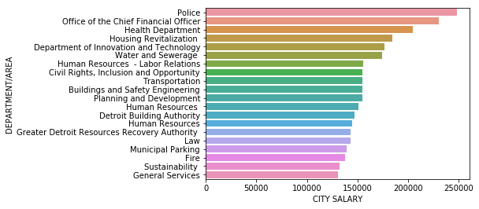

```python
n = 20

filtered_salaries = salaries.filter(['DEPARTMENT/AREA','CITY SALARY'])
grouped_by_dept = filtered_salaries.groupby(['DEPARTMENT/AREA'],as_index=True).mean().sort_values(['CITY SALARY'], ascending=False);

plt.ticklabel_format(style='plain', axis='x')
data=grouped_by_dept.nlargest(n,'CITY SALARY')
sns.barplot(y=data.index, x=data['CITY SALARY'])
grouped_by_dept['CITY SALARY'] = grouped_by_dept.apply(lambda x: "{:,}".format(round(x['CITY SALARY'])), axis=1)

grouped_by_dept.head(n)
```

Initial hypothesis was Mayor's Office will have the highest mean salary - this is definitely false! Highest mean salaries are in Police, Office of the CFO, Health Dept.

**Additional question:** Which departments have the highest total additional grant support?

| DEPARTMENT/AREA | ADDITIONAL GRANT SUPPORT |
| --- | --- |
| Detroit Economic Growth Corporation/Association | 279,000.0 |
| Mayor's Office | 55,000.0 |
| Planning and Development | 30,000.0 |
| Administrative Hearings | 0.0 |

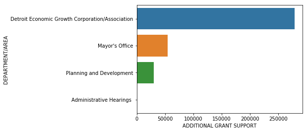

```python
n = 4

filtered_salaries = salaries.filter(['DEPARTMENT/AREA','ADDITIONAL GRANT SUPPORT'])
grouped_by_dept = filtered_salaries.groupby(['DEPARTMENT/AREA'],as_index=True).sum().sort_values(['ADDITIONAL GRANT SUPPORT'], ascending=False);

plt.ticklabel_format(style='plain', axis='x')
data=grouped_by_dept.nlargest(n,'ADDITIONAL GRANT SUPPORT')
sns.barplot(y=data.index, x=data['ADDITIONAL GRANT SUPPORT'])
grouped_by_dept['ADDITIONAL GRANT SUPPORT'] = grouped_by_dept.apply(lambda x: "{:,}".format(round(x['ADDITIONAL GRANT SUPPORT'])), axis=1)

grouped_by_dept.head(n)
```

Detroit Economic Growth has the overwhelming majority of the grant support. (The Detroit Economic Growth Corporation (DEGC) is responsible for several aspects of economic development, including commercial/industrial development and small business promotion, including Motor City Match.) This is to be expected because it is an entire corporation/association and not an individual department. Does Detroit Economic Growth receive a city salary?

```python
salaries[salaries['DEPARTMENT/AREA'] == 'Detroit Economic Growth Corporation/Association']['CITY SALARY']
```

```
53    0.0
Name: CITY SALARY, dtype: float64
```

It appears that Detroit Economic Growth does not receive a city salary. Then it is expected that it receives grant support instead.

Additional question: Which titles have the highest mean city salaries?

| TITLE | CITY SALARY |
| --- | --- |
| Chief of Police | 248,228.0 |
| Chief Financial Officer | 230,625.0 |
| Executive Management Team - Mayor's Office (Group Executive of Operations) | 225,884.0 |
| Executive Director and Health Officer | 205,001.0 |
| Chief Information Officer | 176,505.0 |
| Deputy Director/Chief Engineer Officer | 174,250.0 |
| Director of Government Affairs | 155,072.0 |
| Chief of Staff | 155,072.0 |
| Chief Operating Officer and Senior Counsel | 155,072.0 |
| Group Executive for Jobs and Economy | 154,993.0 |

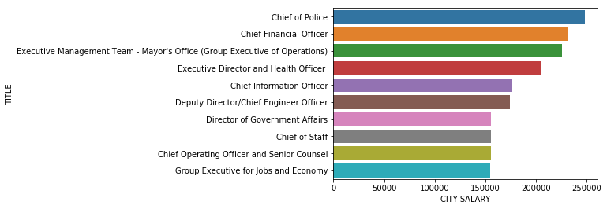

```python
n = 10

filtered_salaries = salaries.filter(['TITLE','CITY SALARY'])
grouped_by_dept = filtered_salaries.groupby(['TITLE'],as_index=True).mean().sort_values(['CITY SALARY'], ascending=False);

plt.ticklabel_format(style='plain', axis='x')
data=grouped_by_dept.nlargest(n,'CITY SALARY')
sns.barplot(y=data.index, x=data['CITY SALARY'])
grouped_by_dept['CITY SALARY'] = grouped_by_dept.apply(lambda x: "{:,}".format(round(x['CITY SALARY'])), axis=1)

grouped_by_dept.head(n)
```

Chief of Police and CFO have the highest salaries.

# Conclusions

Initial hypothesis was Mayor's Office will have the highest mean salary - this is definitely false! Highest mean salaries are in Police, Office of the CFO, Health Dept.

Detroit Economic Growth has the overwhelming majority of the grant support. It appears that Detroit Economic Growth does not receive a city salary.

Chief of Police and CFO have the highest salaries based on title.

Unfortunately, there are no variables here about which we can investigate possible correlations.